# R Notebook

# Statistics X Homework Ch17_Textbook

## 17.3

### a

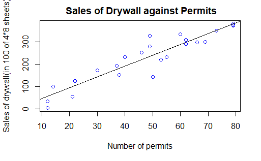

```r
#data processing
data1 <- read.csv("Xr17-03.csv",header = 1)
drywall <- data1$Drywall
permits <- data1$Permits
mortgage <- data1$Mortgage
a_vacancy <- data1$A.Vacancy
o_vacancy <- data1$O.Vacancy
#Scatter diagram
plot(permits,drywall,col="blue",main = " Sales of Drywall against Permits",xlab="Number of permits",ylab="Sales of drywall(in 100 of 4*8 sheets)")
abline(lm(drywall~permits))
```

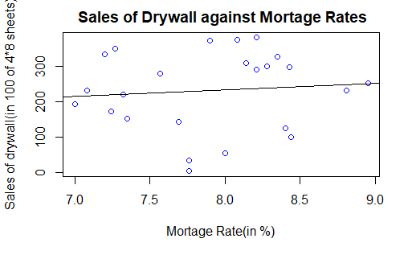

```r
plot(mortgage,drywall,col="blue",main = " Sales of Drywall against Mortage Rates",xlab="Mortage Rate(in %)",ylab="Sales of drywall(in 100 of 4*8 sheets)")
abline(lm(drywall~mortgage))
```

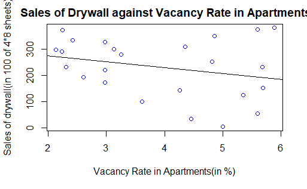

```r
plot(a_vacancy,drywall,col="blue",main = " Sales of Drywall against Vacancy Rate in Apartments",xlab="Vacancy Rate in Apartments(in %)",ylab="Sales of drywall(in 100 of 4*8 sheets)")
abline(lm(drywall~a_vacancy))
```

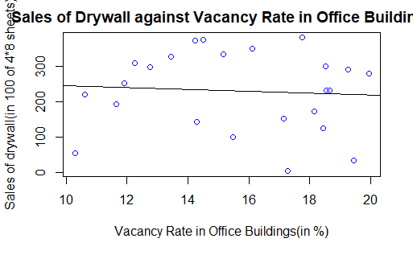

```r
plot(o_vacancy,drywall,col="blue",main = " Sales of Drywall against Vacancy Rate in Office Buildings",xlab="Vacancy Rate in Office Buildings(in %)",ylab="Sales of drywall(in 100 of 4*8 sheets)")
abline(lm(drywall~o_vacancy))
```

```r
#
n <- length(drywall)
Data.Drywall <- cbind(permits,mortgage,a_vacancy,o_vacancy)
linearModelVar <- lm(drywall ~ Data.Drywall)
cat("# # # # The regression model # # # ","\n")
```

```
# # # # The regression model # # #
```

```r
print(summary(linearModelVar))
```

```
Call:
lm(formula = drywall ~ Data.Drywall)

Residuals:
    Min      1Q  Median      3Q     Max
-86.822 -25.351   9.409  22.602  78.391

Coefficients:
                      Estimate Std. Error t value Pr(>|t|)
(Intercept)           -111.828    134.343  -0.832    0.416
Data.Drywallpermits      4.763      0.395  12.057 2.39e-10
Data.Drywallmortgage    16.988     15.159   1.121    0.276
Data.Drywalla_vacancy  -10.528      6.394  -1.646    0.116
Data.Drywallo_vacancy    1.308      2.791   0.469    0.645

(Intercept)
Data.Drywallpermits   ***
Data.Drywallmortgage
Data.Drywalla_vacancy
Data.Drywallo_vacancy
---
Signif. codes:
0 ‘***’ 0.001 ‘**’ 0.01 ‘*’ 0.05 ‘.’ 0.1 ‘ ’ 1

Residual standard error: 40.13 on 19 degrees of freedom
Multiple R-squared:  0.8935,    Adjusted R-squared:  0.8711
F-statistic: 39.86 on 4 and 19 DF,  p-value: 5.448e-09
```

```r
ANOVA_T_lm <- anova(linearModelVar)
cat("# # # # The ANOVA Table # # # ","\n")
```

```
# # # # The ANOVA Table # # #
```

```r
print(ANOVA_T_lm)
```

```
Analysis of Variance Table

Response: drywall
             Df Sum Sq Mean Sq F value    Pr(>F)
Data.Drywall  4 256793   64198   39.86 5.448e-09 ***
Residuals    19  30602    1611
---
Signif. codes:
0 ‘***’ 0.001 ‘**’ 0.01 ‘*’ 0.05 ‘.’ 0.1 ‘ ’ 1
```

```
Propose a statistical model:
```

$$y\ =\ \beta_0\ +\ \beta_1x_1\ +\ \beta_2x_2\ +\ \beta_3x_3\ +\ \beta_4x_4\ +\ \varepsilon$$

y = the monthly sales of drywall(in 100 of 4*8 sheets)

$x_1$ = the number of building permits issued in the county

$x_2$ = 5-year mortage rates(in %)

$x_3$ = vacancy rate in apartments(in %)

$x_4$ = vacancy rate in office buildings(in %)

$\varepsilon$ = error variable

[output not shown]

```r
cat("mean of y = ",mean(drywall))
```

```
mean of y =  230.9583
```

It seems that $s_{\varepsilon}$ is small compared to $\bar{y}$ = 230.96. We can conclude the model fit the data well.

## answer

### c

From the print out, the coefficient of determination $r^2$ is 0.8935.

The adjusted coefficient of determination 0.8711 is close to 0.8935( $\leq$ 0.06), indicating that the model has no problem of over-fitting.

According to the coefficient of determination, we can say that 89.35% of the variation in sales of drywall is explained by this regression line of the 4 independent variables and 10.65% remains unexplained.

### d

We use the F-test of ANOVA to test the validity of the model. Hypothesis:

$$H_0: \beta_1\ =\ \beta_2\ =\ \beta_3\ =\ \beta_4\ =\ 0\\
H_1: At\ least\ one\ \beta_i\ is\ not\ equal\ to\ 0.$$

```r
linearModelVar <- lm(drywall ~ Data.Drywall)
ANOVA_T_lm <- anova(linearModelVar)
cat("# # # # The ANOVA Table # # # ","\n")
```

```
# # # # The ANOVA Table # # #
```

```r
print(ANOVA_T_lm)
```

```
Analysis of Variance Table

Response: drywall
             Df Sum Sq Mean Sq F value    Pr(>F)
Data.Drywall  4 256793   64198   39.86 5.448e-09 ***
Residuals    19  30602    1611
---
Signif. codes:
0 ‘***’ 0.001 ‘**’ 0.01 ‘*’ 0.05 ‘.’ 0.1 ‘ ’ 1
```

```
Conclusion:
```

Since p value 5.448e-09 < 0.05, we reject $H_0$. There is sufficient evidence to say that at least one of the $b_i$ is not equal to zero. Thus, at least one independent variable is related to y. This regression model is valid.

### e

```
Interpret:
```

$$\hat{y}\ =\ b_0\ +\ b_1x_1\ +\ b_2x_2\ +\ b_3x_3\ +\ b_4x_4\\
=\ -111.828\ +\ 4.763x_1 \ +\ 16.988x_2\ -\ 10.528 x_3\ +\ 1.308 x_4\$$

1. $b_0$  
   $b_0$ = -111.828. This is the intercept, the value of y when all the variables take the value zero. Since the data range of all the independent variables do not cover the value zero, do not interpret the intercept.
2. $b_1$  
   $b_1$ = 4.763. In this model, for each additional number of building permits, the sales of drywall increases on the average by 4.763 $hundred\ sheets$ (assuming the other variables are held constant).
3. $b_2$  
   $b_2$ = 16.988. In this model, for each additional mortgage rate(in %), the sales of drywall increases on the average by 16.988 $hundred\ sheets$ (assuming the other variables are held constant).
4. $b_3$  
   $b_3$ = -10.528. In this model, for each additional vacancy rate(in %) in apartments, the sales of drywall decreases on the average by 10.528 $hundred\ sheets$ (assuming the other variables are held constant).
5. $b_4$  
   $b_4$ = 1.308. In this model, for each additional vacancy rate(in %) in office buildings, the sales of drywall increases on the average by 1.308 $hundred\ sheets$ (assuming the other variables are held constant).

### f

Use the t-test of the coefficient of correlation to determine if each $b_i$ is linearly related to drywall demand. Hypothesis for each independent variable:

$$H_0:\rho\ =\ 0\\
H_1:\rho\ \neq\ 0$$
For $b_1$:

```r
test_cor <- cor.test(drywall, permits,alternative = "two.sided")
cat("# # # # The test of Coefficient of Correlation # # # ","\n")
```

```
# # # # The test of Coefficient of Correlation # # #
```

```r
print(test_cor)
```

```
    Pearson's product-moment correlation

data:  drywall and permits
t = 12.123, df = 22, p-value = 3.27e-11
alternative hypothesis: true correlation is not equal to 0
95 percent confidence interval:
 0.8484177 0.9707921
sample estimates:
      cor
0.9326246
```

```
Conclusion:
```

Since p-value = 3.27e-11 < 0.05, we reject H0. There is sufficient evidence at a = 5% to infer that there is a linear relationship between $b_1$ and y.

For $b_2$:

```r
test_cor <- cor.test(drywall, mortgage,alternative = "two.sided")
cat("# # # # The test of Coefficient of Correlation # # # ","\n")
```

```
# # # # The test of Coefficient of Correlation # # #
```

```r
print(test_cor)
```

```
    Pearson's product-moment correlation

data:  drywall and mortgage
t = 0.43373, df = 22, p-value = 0.6687
alternative hypothesis: true correlation is not equal to 0
95 percent confidence interval:
 -0.3233284  0.4777300
sample estimates:
       cor
0.09207805
```

```
Conclusion:
```

Since p-value = 0.6687 > 0.05, we do not reject H0. There is no sufficient evidence at a = 5% to infer that there is a linear relationship between $b_2$ and y.

For $b_3$:

```r
test_cor <- cor.test(drywall, a_vacancy,alternative = "two.sided")
cat("# # # # The test of Coefficient of Correlation # # # ","\n")
```

```
# # # # The test of Coefficient of Correlation # # #
```

```r
print(test_cor)
```

```
    Pearson's product-moment correlation

data:  drywall and a_vacancy
t = -1.2835, df = 22, p-value = 0.2127
alternative hypothesis: true correlation is not equal to 0
95 percent confidence interval:
 -0.6031227  0.1560715
sample estimates:
       cor
-0.2639427
```

```
Conclusion:
```

Since p-value = 0.2127 > 0.05, we do not reject H0. There is no sufficient evidence at a = 5% to infer that there is a linear relationship between $b_3$ and y.

For $b_4$:

```r
test_cor <- cor.test(drywall, o_vacancy,alternative = "two.sided")
cat("# # # # The test of Coefficient of Correlation # # # ","\n")
```

```
# # # # The test of Coefficient of Correlation # # #
```

```r
print(test_cor)
```

```
    Pearson's product-moment correlation

data:  drywall and o_vacancy
t = -0.32809, df = 22, p-value = 0.7459
alternative hypothesis: true correlation is not equal to 0
95 percent confidence interval:
 -0.4602200  0.3432819
sample estimates:
        cor
-0.06977757
```

```
Conclusion:
```

Since p-value = 0.7459 > 0.05, we do not reject H0. There is no sufficient evidence at a = 5% to infer that there is a linear relationship between $b_4$ and y.

### g

Predict next month’s drywall sales with 95% confidence if the number of building permits is 50, the 5-year mortgage rate is 9.0%, and the vacancy rates are 3.6% in apartments and 14.3% in office buildings. Use prediction interval:

```r
Data.Drywall <- cbind(permits,mortgage,a_vacancy,o_vacancy)
linearModelVar <- lm(drywall ~ Data.Drywall)
newdata = data.frame(Data.Drywall <- cbind(50, 9,3.6,14.3) )
PI <- predict(linearModelVar, newdata, interval="predict")
cat("# # # # The prediction interval # # # ","\n")
```

```
# # # # The prediction interval # # #
```

```r
print(PI)
```

```
       fit      lwr      upr
1 260.0254 167.1212 352.9296
```

```
Conclusion:
```

At 95% confidence level, the interval, [167.1212, 352.9296], covers the next month’s drywall sales if the number of building permits is 50, the 5-year mortgage rate is 9.0%, and the vacancy rates are 3.6% in apartments and 14.3% in office buildings.

## Residual Analysis

```
Standardized residuals:
```

```r
standarized_errors_MR <- function(y, x) {
   n <- length(y)
   k <- ncol(x)
   x1 <- vector("double", length = n)
   for(j in 1:n) {
      x1[j] <- 1
      }
   Matrix_X <- cbind(x1, x)
   Matrix_Y <- cbind(y)
   Matrix_H <-  Matrix_X%*%solve(t(Matrix_X)%*%Matrix_X)%*%t(Matrix_X)
   Matrix_YP <-  Matrix_H%*%Matrix_Y
   y_p <- Matrix_YP[,1]
   h <- vector("double", length = n)
   D <- vector("double", length = n)
      Error <- vector("double", length = n)
   Standard_E <- vector("double", length = n)
   se <- sqrt(sum((y - y_p)^2)/(n - k - 1))
   for(i in 1:n) {
      h[i] <- Matrix_H[i,i]
      Error[i] <- y[i] - y_p[i]
      Standard_E[i] <- Error[i] / (se * sqrt(1 - h[i]))
      D[i] <- (y[i] - y_p[i])^2 * h[i] / ((k -1) * se^2 * (1 - h[i])^2)
      }
   SEhD <- cbind(Standard_E, h, D)
   return(SEhD)
}
#
n <- length(drywall)
Data.Drywall <- cbind(permits,mortgage,a_vacancy,o_vacancy)
linearModelVar <- lm(drywall ~ Data.Drywall)
SE <- standarized_errors_MR(drywall, Data.Drywall)[,1]
h <- standarized_errors_MR(drywall, Data.Drywall)[,2]
D <- standarized_errors_MR(drywall, Data.Drywall)[,3]
print(SE)
```

```
 [1]  2.0728732  0.4068178 -0.5680216 -2.2314624  0.6842512
 [6] -0.7853130  0.6307879 -1.3016241 -0.7506256  0.8205666
[11]  0.4694780  0.7367955 -0.1240052  0.6001194 -0.0538226
[16] -0.5823194 -0.9736954 -1.1626043  1.2203271  1.0318563
[21]  0.5737238 -1.2003317  0.4538470  0.1343434
```

1. Normality

   Hypothesis:

$$H_0:Errors\ are\ normally\ distributed.\\
H_1:Errors\ are\ not\ normally\ distributed.$$

```
Apply the Shapiro-Wilks test of normality.
```

```r
SE <- standarized_errors_MR(drywall, Data.Drywall)[,1]
cat("# # # # The Normality Test # # # ","\n")
```

```
# # # # The Normality Test # # #
```

```r
norm_test <- shapiro.test(SE)
print(norm_test)
```

```
    Shapiro-Wilk normality test

data:  SE
W = 0.9687, p-value = 0.6351
```

Because p_value = 0.6351 > 0.05, we do not rejected H0. We can NOT infer that errors are not normally distributed.

2. Homoscedasticity or Heteroscedasticity

   Hypothesis:

$$H_0:Homoscedasticity\\
H_1:Heteroscedasticity$$

```
Scatter plot:
```

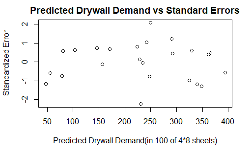

```r
n <- length(drywall)
Data.Drywall <- cbind(permits,mortgage,a_vacancy,o_vacancy)
linearModelVar <- lm(drywall ~ Data.Drywall)
SE <- standarized_errors_MR(drywall, Data.Drywall)[,1]
a <- coef(linearModelVar)[1]
b <- coef(linearModelVar)[2]
c <- coef(linearModelVar)[3]
d <- coef(linearModelVar)[4]
e <- coef(linearModelVar)[5]
Price_p <- vector("double", length = n)
  for(i in 1:n) {
    Price_p[i] <- a + b * permits[i] + c * mortgage[i] + d * a_vacancy[i] + e * o_vacancy[i]
  }
plot(x = Price_p,y = SE,  xlab = "Predicted Drywall Demand(in 100 of 4*8 sheets)",  ylab = "Standardized Error", main = "Predicted Drywall Demand vs Standard Errors")
```

Conclusion: Do not Rejected H0. We can assume that the variation is constant and the mean is around 0.

3. Dependence of the Error Variable

   Hypothesis:

$$H_0:\ Randomness\ exists.\\
H_1:\ Randomness\ does\ not\ exist.$$

```r
library(randtests)
SE <- standarized_errors_MR(drywall, Data.Drywall)[,1]
Run_T <- runs.test(SE)
print(Run_T)
```

```
    Runs Test

data:  SE
statistic = 0.41742, runs = 14, n1 = 12, n2 = 12, n
= 24, p-value = 0.6764
alternative hypothesis: nonrandomness
```

Conclusion: When n1=12 and n2=12 (both less than 20), the lower bound k1=7 and the upper bound k2=19 (according to the table in the Powerpoint). Since k1=7< Runs=14 < k2=19, we don’t reject H0. There is no evidence to infer that the sample is not random.

## Outliers and Influential Obs

```r
n <- length(drywall)
Data.Drywall <- cbind(permits,mortgage,a_vacancy,o_vacancy)
linearModelVar <- lm(drywall ~ Data.Drywall)
SE <- standarized_errors_MR(drywall, Data.Drywall)[,1]
h <- standarized_errors_MR(drywall, Data.Drywall)[,2]
D <- standarized_errors_MR(drywall, Data.Drywall)[,3]
#
cat("# # # # Outliers # # # ","\n")
```

```
# # # # Outliers # # #
```

```r
Outliers <- abs(SE) > 2
print(Outliers)
```

```
 [1]  TRUE FALSE FALSE  TRUE FALSE FALSE FALSE FALSE FALSE
[10] FALSE FALSE FALSE FALSE FALSE FALSE FALSE FALSE FALSE
[19] FALSE FALSE FALSE FALSE FALSE FALSE
```

```r
cat("     ","\n")
```

```r
cat("# # # # Influential Observations by h # # # ","\n")
```

```
# # # # Influential Observations by h # # #
```

```r
k <- dim(Data.Drywall)[2]
Inf_Obs <- h > 3*(k+1)/n
print(Inf_Obs)
```

```
 [1] FALSE FALSE FALSE FALSE FALSE FALSE FALSE FALSE FALSE
[10] FALSE FALSE FALSE FALSE FALSE FALSE FALSE FALSE FALSE
[19] FALSE FALSE FALSE FALSE FALSE FALSE
```

```r
cat("     ","\n")
```

```r
cat("# # # # Influential Observations # # # ","\n")
```

```
# # # # Influential Observations # # #
```

```r
Inf_Obs <- D > 1
print(Inf_Obs)
```

```
 [1] FALSE FALSE FALSE FALSE FALSE FALSE FALSE FALSE FALSE
[10] FALSE FALSE FALSE FALSE FALSE FALSE FALSE FALSE FALSE
[19] FALSE FALSE FALSE FALSE FALSE FALSE
```

Conclusion: Samples 1,4 are outliers because their standardized residuals are larger than 2 or smaller than –2. None of the samples is influential observation because neither of their h is larger than 3*(k+1)/n or $D_i$ > 1.

## 17.7

### a

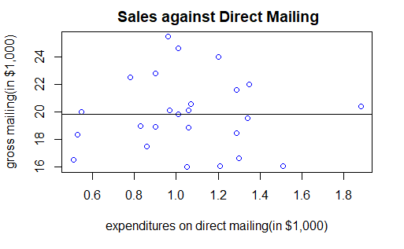

```r
#data processing
data2 <- read.csv("Xr17-07.csv",header = 1)
sales <- data2$Sales
direct <- data2$Direct
newspaper <- data2$Newspaper
TV <- data2$Television
##Scatter diagram
plot(direct,sales,col="blue",main = " Sales against Direct Mailing",xlab="expenditures on direct mailing(in $1,000)",ylab="gross mailing(in $1,000)")
abline(lm(sales~direct))
```

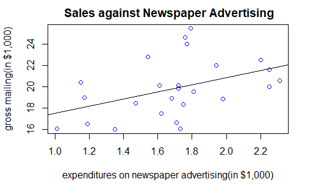

```r
plot(newspaper,sales,col="blue",main = " Sales against Newspaper Advertising",xlab="expenditures on newspaper advertising(in $1,000)",ylab="gross mailing(in $1,000)")
abline(lm(sales~newspaper))
```

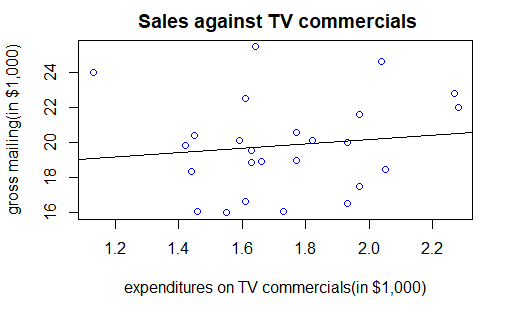

```r
plot(TV,sales,col="blue",main = " Sales against TV commercials",xlab="expenditures on TV commercials(in $1,000)",ylab="gross mailing(in $1,000)")
abline(lm(sales~TV))
```

```r
#
n <- length(sales)
Data.Sales <- cbind(direct,newspaper,TV)
linearModelVar <- lm(sales ~ Data.Sales)
cat("# # # # The regression model # # # ","\n")
```

```
# # # # The regression model # # #
```

```r
print(summary(linearModelVar))
```

```
Call:
lm(formula = sales ~ Data.Sales)

Residuals:
    Min      1Q  Median      3Q     Max
-4.1592 -1.4529 -0.7043  0.9982  5.4709

Coefficients:
                    Estimate Std. Error t value Pr(>|t|)
(Intercept)          12.3084     4.6982   2.620   0.0160 *
Data.Salesdirect      0.5699     1.7203   0.331   0.7437
Data.Salesnewspaper   3.3200     1.5390   2.157   0.0427 *
Data.SalesTV          0.7322     1.9584   0.374   0.7123
---
Signif. codes:
0 ‘***’ 0.001 ‘**’ 0.01 ‘*’ 0.05 ‘.’ 0.1 ‘ ’ 1

Residual standard error: 2.587 on 21 degrees of freedom
Multiple R-squared:  0.1953,    Adjusted R-squared:  0.08029
F-statistic: 1.698 on 3 and 21 DF,  p-value: 0.1979
```

```
Propose a statistical model:
```

$$y\ =\ \beta_0\ +\ \beta_1x_1\ +\ \beta_2x_2\ +\ \beta_3x_3\ +\ \varepsilon$$

y = sales(in $1,000)

$x_1$ = expenditures on direct mailing(in $1,000)

$x_2$ = expenditures on newspaper advertising(in $1,000)

$x_3$ = expenditures on TV commercials(in $1,000)

$\varepsilon$ = error variable

```
From the printout, we can get the multiple regression equation:
```

$$\hat{y} =\ 12.3084\ +\ 0.5699x_1 \ +\ 3.3200 x_2\ +\ 0.7322x_3$$

### b

From the print out, the coefficient of determination $r^2$ is 0.1953.

According to the statistic, we can say that 19.53% of the variation in sales is explained by this regression line of the 3 independent variables and 80.47% remains unexplained.

The adjusted coefficient of determination 0.08029 is not close enough to 0.1953( $\geq$ 0.06), indicating that the model has problem of over-fitting.

### c

From the printout, $s_{\varepsilon}$ = 2.587

We can use this statistic to assess the model’s fit by comparing to the mean of y.

```r
cat("mean of y = ",mean(sales))
```

```
mean of y =  19.8216
```

It seems that $s_{\varepsilon}$ is small compared to $\bar{y}$ = 19.8216.

### d

We use the F-test of ANOVA to test the validity of the model. Hypothesis:

$$H_0: \beta_1\ =\ \beta_2\ =\ \beta_3\ =\ 0\\
H_1: At\ least\ one\ \beta_i\ is\ not\ equal\ to\ 0.$$

```r
linearModelVar <- lm(sales ~ Data.Sales)
ANOVA_T_lm <- anova(linearModelVar)
cat("# # # # The ANOVA Table # # # ","\n")
```

```
# # # # The ANOVA Table # # #
```

```r
print(ANOVA_T_lm)
```

```
Analysis of Variance Table

Response: sales
           Df  Sum Sq Mean Sq F value Pr(>F)
Data.Sales  3  34.104 11.3679  1.6984 0.1979
Residuals  21 140.560  6.6933
```

```
Conclusion:
```

Since p value 0.1979 > 0.05, we do NOT reject $H_0$. There is no sufficient evidence to say that at least one of the $b_i$ is not equal to zero. Thus, this regression model is not valid.

### e

Use the t-test of the coefficient of correlation to determine which independent variables are linearly related to weekly gross sales.

```
Hypothesis for each independent variable:
```

$$H_0:\rho\ =\ 0\\
H_1:\rho\ \neq\ 0$$

```
Multiple Regression equation:
```

$$\hat{y}\ =\ b_0\ +\ b_1x_1\ +\ b_2x_2\ +\ b_3x_3\\
=\ 12.3084\ +\ 0.5699x_1 \ +\ 3.3200 x_2\ +\ 0.7322x_3$$

For $b_1$:

```r
test_cor <- cor.test(sales, direct,alternative = "two.sided")
cat("# # # # The test of Coefficient of Correlation # # # ","\n")
```

```
# # # # The test of Coefficient of Correlation # # #
```

```r
print(test_cor)
```

```
    Pearson's product-moment correlation

data:  sales and direct
t = -0.012588, df = 23, p-value = 0.9901
alternative hypothesis: true correlation is not equal to 0
95 percent confidence interval:
 -0.3973435  0.3929137
sample estimates:
         cor
-0.002624742
```

Since p-value = 0.9901 > 0.05, we do not reject H0. There is no sufficient evidence at a = 5% to infer that there is a linear relationship between $b_1$ and y.

For $b_2$:

```r
test_cor <- cor.test(sales, newspaper,alternative = "two.sided")
cat("# # # # The test of Coefficient of Correlation # # # ","\n")
```

```
# # # # The test of Coefficient of Correlation # # #
```

```r
print(test_cor)
```

```
    Pearson's product-moment correlation

data:  sales and newspaper
t = 2.2971, df = 23, p-value = 0.03105
alternative hypothesis: true correlation is not equal to 0
95 percent confidence interval:
 0.04443131 0.70651551
sample estimates:
      cor
0.4319783
```

Since p-value = 0.03105 < 0.05, we reject H0. There is sufficient evidence at a = 5% to infer that there is a linear relationship between $b_2$ and y.

For $b_3$:

```r
test_cor <- cor.test(sales, TV,alternative = "two.sided")
cat("# # # # The test of Coefficient of Correlation # # # ","\n")
```

```
# # # # The test of Coefficient of Correlation # # #
```

```r
print(test_cor)
```

```
    Pearson's product-moment correlation

data:  sales and TV
t = 0.62548, df = 23, p-value = 0.5378
alternative hypothesis: true correlation is not equal to 0
95 percent confidence interval:
 -0.2801195  0.4989595
sample estimates:
      cor
0.1293257
```

Since p-value = 0.5378 > 0.05, we do not reject H0. There is no sufficient evidence at a = 5% to infer that there is a linear relationship between $b_3$ and y. Overall conclusion: Due to results of above, $b_2$(newspaper) is linearly related to weekly gross sales in this model.

### f

Compute the week’s gross sales with 95% confidence if a local store spent $800 on direct mailing, $1,200 on newspaper advertisements, and $2,000 on TV commercials. Use prediction interval:

```r
Data.Sales <- cbind(direct,newspaper,TV)
linearModelVar <- lm(sales ~ Data.Sales)
newdata = data.frame(Data.Sales <- cbind(0.8,1.2,2) )
PI <- predict(linearModelVar, newdata, interval="predict")
cat("# # # # The prediction interval # # # ","\n")
```

```
# # # # The prediction interval # # #
```

```r
print(PI)
```

```
       fit      lwr      upr
1 18.21266 12.27324 24.15208
```

```
Conclusion:
```

At 95% confidence level, the interval, 12.27324 ,24.15208, covers the week’s gross sales with 95% confidence if a local store spent $800 on direct mailing, $1,200 on newspaper advertisements, and $2,000 on TV commercials.

### g

Calculate the mean weekly gross sales for all stores with 95% confidence that spent $800 on direct mailing, $1,200 on newspaper advertisements, and $2,000 on TV commercials. Use confidence interval:

```r
Data.Sales <- cbind(direct,newspaper,TV)
linearModelVar <- lm(sales ~ Data.Sales)
newdata = data.frame(Data.Sales <- cbind(0.8,1.2,2) )
CI <- predict(linearModelVar, newdata, interval="confidence")
cat("# # # # The confidence interval # # # ","\n")
```

```
# # # # The confidence interval # # #
```

```r
print(CI)
```

```
       fit      lwr      upr
1 18.21266 15.69681 20.72851
```

```
Conclusion:
```

At 95% confidence level, the interval, 15.69681, 20.72851, covers the mean weekly gross sales for all stores that spent $800 on direct mailing, $1,200 on newspaper advertisements, and $2,000 on TV commercials.

### h

The 2 intervals in (f) and (g) have a difference, since the prediction interval is wider than the confidence interval.

## Residual Analysis

```
Standardized residuals:
```

```r
standarized_errors_MR <- function(y, x) {
   n <- length(y)
   k <- ncol(x)
   x1 <- vector("double", length = n)
   for(j in 1:n) {
      x1[j] <- 1
      }
   Matrix_X <- cbind(x1, x)
   Matrix_Y <- cbind(y)
   Matrix_H <-  Matrix_X%*%solve(t(Matrix_X)%*%Matrix_X)%*%t(Matrix_X)
   Matrix_YP <-  Matrix_H%*%Matrix_Y
   y_p <- Matrix_YP[,1]
   h <- vector("double", length = n)
   D <- vector("double", length = n)
      Error <- vector("double", length = n)
   Standard_E <- vector("double", length = n)
   se <- sqrt(sum((y - y_p)^2)/(n - k - 1))
   for(i in 1:n) {
      h[i] <- Matrix_H[i,i]
      Error[i] <- y[i] - y_p[i]
      Standard_E[i] <- Error[i] / (se * sqrt(1 - h[i]))
      D[i] <- (y[i] - y_p[i])^2 * h[i] / ((k -1) * se^2 * (1 - h[i])^2)
      }
   SEhD <- cbind(Standard_E, h, D)
   return(SEhD)
}
#
n <- length(sales)
Data.Sales <- cbind(direct,newspaper,TV)
linearModelVar <- lm(sales ~ Data.Sales)
SE <- standarized_errors_MR(sales, Data.Sales)[,1]
h <- standarized_errors_MR(sales, Data.Sales)[,2]
D <- standarized_errors_MR(sales, Data.Sales)[,3]
print(SE)
```

```
 [1] -1.03367871 -0.15875710  2.17333728 -1.72586989
 [5] -1.33435959  0.20193694 -0.86276795  0.54883639
 [9]  1.92058800  0.42493667  1.79248761 -0.30533233
[13] -0.67727382 -0.73229536  1.40502044  1.06302541
[17] -0.67761077 -0.50832595 -0.60572822 -0.28012280
[21]  0.14099331  0.07981823 -0.42160983  0.36478964
[25] -0.55756421
```

1. Normality

   Hypothesis:

$$H_0:Errors\ are\ normally\ distributed.\\
H_1:Errors\ are\ not\ normally\ distributed.$$

```
Apply the Shapiro-Wilks test of normality.
```

```r
SE <- standarized_errors_MR(sales, Data.Sales)[,1]
cat("# # # # The Normality Test # # # ","\n")
```

```
# # # # The Normality Test # # #
```

```r
norm_test <- shapiro.test(SE)
print(norm_test)
```

```
    Shapiro-Wilk normality test

data:  SE
W = 0.94162, p-value = 0.1614
```

Because p_value = 0.1614 > 0.05, we do not rejected H0. We can NOT infer that errors are not normally distributed.

2. Homoscedasticity or Heteroscedasticity:

   Hypothesis:

$$H_0:Homoscedasticity\\
H_1:Heteroscedasticity$$

```
Scatter plot:
```

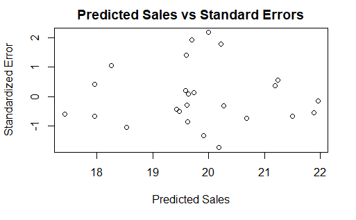

```r
n <- length(sales)
Data.Sales <- cbind(direct,newspaper,TV)
linearModelVar <- lm(sales ~ Data.Sales)
SE <- standarized_errors_MR(sales, Data.Sales)[,1]
a <- coef(linearModelVar)[1]
b <- coef(linearModelVar)[2]
c <- coef(linearModelVar)[3]
d <- coef(linearModelVar)[4]
Price_p <- vector("double", length = n)
  for(i in 1:n) {
    Price_p[i] <- a + b * direct[i] + c * newspaper[i] + d * TV[i]
  }
plot(x = Price_p,y = SE,  xlab = "Predicted Sales",  ylab = "Standardized Error", main = "Predicted Sales vs Standard Errors")
```

Conclusion: Do not Rejected H0. We can assume that the variation is constant and the mean is around 0.

3. Dependence of the Error Variable

   Hypothesis:

$$H_0:\ Randomness\ exists.\\
H_1:\ Randomness\ does\ not\ exist.$$

```r
library(randtests)
library(snpar)
n <- length(sales)
SE <- standarized_errors_MR(sales, Data.Sales)[,1]
Run_T <- runs.test(SE)
#cat(length(SE))
print(Run_T)
```

```
    Approximate runs rest

data:  SE
Runs = 13, p-value = 0.8443
alternative hypothesis: two.sided
```

```r
n <- length(sales)
Data.Sales <- cbind(direct,newspaper,TV)
linearModelVar <- lm(sales ~ Data.Sales)
SE <- standarized_errors_MR(sales, Data.Sales)[,1]
h <- standarized_errors_MR(sales, Data.Sales)[,2]
D <- standarized_errors_MR(sales, Data.Sales)[,3]
#
cat("# # # # Outliers # # # ","\n")
```

```
# # # # Outliers # # #
```

```r
Outliers <- abs(SE) > 2
print(Outliers)
```

```
 [1] FALSE FALSE  TRUE FALSE FALSE FALSE FALSE FALSE FALSE
[10] FALSE FALSE FALSE FALSE FALSE FALSE FALSE FALSE FALSE
[19] FALSE FALSE FALSE FALSE FALSE FALSE FALSE
```

```r
cat("     ","\n")
```

```r
cat("# # # # Influential Observations by h # # # ","\n")
```

```
# # # # Influential Observations by h # # #
```

```r
k <- dim(Data.Sales)[2]
Inf_Obs <- h > 3*(k+1)/n
print(Inf_Obs)
```

```
 [1] FALSE FALSE FALSE FALSE FALSE FALSE FALSE FALSE FALSE
[10] FALSE FALSE FALSE FALSE FALSE FALSE FALSE FALSE FALSE
[19] FALSE FALSE FALSE FALSE FALSE FALSE FALSE
```

```r
cat("     ","\n")
```

```r
cat("# # # # Influential Observations # # # ","\n")
```

```
# # # # Influential Observations # # #
```

```r
Inf_Obs <- D > 1
print(Inf_Obs)
```

```
 [1] FALSE FALSE FALSE FALSE FALSE FALSE FALSE FALSE FALSE
[10] FALSE FALSE FALSE FALSE FALSE FALSE FALSE FALSE FALSE
[19] FALSE FALSE FALSE FALSE FALSE FALSE FALSE
```

Conclusion: Sample 3 is an outlier because its standardized residual is larger than 2 or smaller than –2. None of the samples is influential observation because neither of their h is larger than 3*(k+1)/n or $D_i$ > 1.

## 17.13

### a

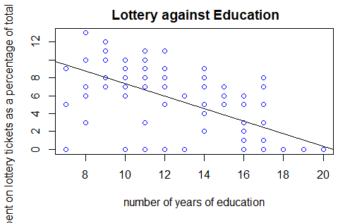

```r
#data processing
data3 <- read.csv("Xr17-13.csv",header = 1)
lottery <- data3$Lottery
education <- data3$Education
age <- data3$Age
children <- data3$Children
income <- data3$Income
#Scatter diagram
plot(education,lottery,col="blue",main = " Lottery against Education",xlab="number of years of education",ylab="amount spent on lottery tickets as a percentage of total household income")
abline(lm(lottery~education))
```

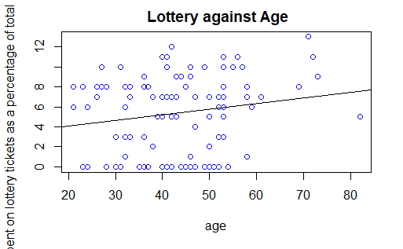

```r
plot(age,lottery,col="blue",main = " Lottery against Age",xlab="age",ylab="amount spent on lottery tickets as a percentage of total household income")
abline(lm(lottery~age))
```

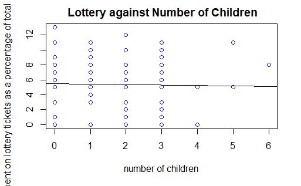

```r
plot(children,lottery,col="blue",main = " Lottery against Number of Children",xlab="number of children",ylab="amount spent on lottery tickets as a percentage of total household income")
abline(lm(lottery~children))
```

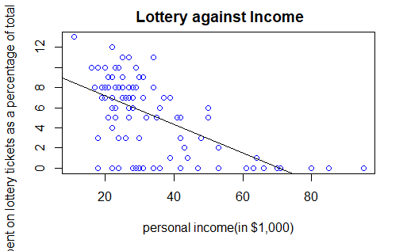

```r
plot(income,lottery,col="blue",main = " Lottery against Income",xlab="personal income(in $1,000)",ylab="amount spent on lottery tickets as a percentage of total household income")
abline(lm(lottery~income))
```

```r
#
Data.Lottery <- cbind(education,age,children,income)
linearModelVar <- lm(lottery ~ Data.Lottery)
cat("# # # # The regression model # # # ","\n")
```

```
# # # # The regression model # # #
```

```r
print(summary(linearModelVar))
```

```
Call:
lm(formula = lottery ~ Data.Lottery)

Residuals:
    Min      1Q  Median      3Q     Max
-8.5245 -1.3062  0.2443  1.9294  5.1222

Coefficients:
                      Estimate Std. Error t value Pr(>|t|)
(Intercept)           11.90609    1.78520   6.669 1.69e-09
Data.Lotteryeducation -0.43002    0.13207  -3.256  0.00157
Data.Lotteryage        0.02919    0.02523   1.157  0.25015
Data.Lotterychildren   0.09344    0.22431   0.417  0.67796
Data.Lotteryincome    -0.07447    0.02773  -2.686  0.00854

(Intercept)           ***
Data.Lotteryeducation **
Data.Lotteryage
Data.Lotterychildren
Data.Lotteryincome    **
---
Signif. codes:
0 ‘***’ 0.001 ‘**’ 0.01 ‘*’ 0.05 ‘.’ 0.1 ‘ ’ 1

Residual standard error: 2.91 on 95 degrees of freedom
Multiple R-squared:  0.4335,    Adjusted R-squared:  0.4096
F-statistic: 18.17 on 4 and 95 DF,  p-value: 4.094e-11
```

```
Propose a statistical model:
```

$$y\ =\ \beta_0\ +\ \beta_1x_1\ +\ \beta_2x_2\ +\ \beta_3x_3\ +\ \beta_4x_4\ +\ \varepsilon$$

y = amount spent on lottery tickets as a percentage of total household income

$x_1$ = number of years of education

$x_2$ = age

$x_3$ = number of children

$x_4$ = personal income(in $1,000)

$\varepsilon$ = error variable

```
From the printout, we can get the multiple regression model:
```

$$\hat{y} =\ 11.90609 \ -\ 0.43002 x_1 \ +\ 0.02919x_2\ +\ 0.09344x_3\ -\ 0.07447x_4\$$

### b

We use the F-test of ANOVA to test the validity of the model.

```
Hypothesis:
```

$$H_0: \beta_1\ =\ \beta_2\ =\ \beta_3\ =\ \beta_4\ =\ 0\\
H_1: At\ least\ one\ \beta_i\ is\ not\ equal\ to\ 0.$$

```r
linearModelVar <- lm(lottery ~ Data.Lottery)
ANOVA_T_lm <- anova(linearModelVar)
cat("# # # # The ANOVA Table # # # ","\n")
```

```
# # # # The ANOVA Table # # #
```

```r
print(ANOVA_T_lm)
```

```
Analysis of Variance Table

Response: lottery
             Df Sum Sq Mean Sq F value    Pr(>F)
Data.Lottery  4 615.44 153.861  18.172 4.094e-11 ***
Residuals    95 804.35   8.467
---
Signif. codes:
0 ‘***’ 0.001 ‘**’ 0.01 ‘*’ 0.05 ‘.’ 0.1 ‘ ’ 1
```

```
Conclusion:
```

Since p value 4.094e-11 < 0.05, we reject $H_0$. There is sufficient evidence to say that at least one of the $b_i$ is not equal to zero. Thus, at least one independent variable is related to y. This regression model is valid.

### c

$$\hat{y}\ =\ b_0\ +\ b_1x_1\ +\ b_2x_2\ +\ b_3x_3\ +\ b_4x_4\\
=\ 11.90609 \ -\ 0.43002 x_1 \ +\ 0.02919x_2\ +\ 0.09344x_3\ -\ 0.07447x_4\$$

## Residual Analysis

```
Standardized residuals:
```

```r
standarized_errors_MR <- function(y, x) {
   n <- length(y)
   k <- ncol(x)
   x1 <- vector("double", length = n)
   for(j in 1:n) {
      x1[j] <- 1
      }
   Matrix_X <- cbind(x1, x)
   Matrix_Y <- cbind(y)
   Matrix_H <-  Matrix_X%*%solve(t(Matrix_X)%*%Matrix_X)%*%t(Matrix_X)
   Matrix_YP <-  Matrix_H%*%Matrix_Y
   y_p <- Matrix_YP[,1]
   h <- vector("double", length = n)
   D <- vector("double", length = n)
      Error <- vector("double", length = n)
   Standard_E <- vector("double", length = n)
   se <- sqrt(sum((y - y_p)^2)/(n - k - 1))
   for(i in 1:n) {
      h[i] <- Matrix_H[i,i]
      Error[i] <- y[i] - y_p[i]
      Standard_E[i] <- Error[i] / (se * sqrt(1 - h[i]))
      D[i] <- (y[i] - y_p[i])^2 * h[i] / ((k -1) * se^2 * (1 - h[i])^2)
      }
   SEhD <- cbind(Standard_E, h, D)
   return(SEhD)
}
#
n <- length(lottery)
Data.Lottery <- cbind(education,age,children,income)
linearModelVar <- lm(lottery ~ Data.Lottery)
SE <- standarized_errors_MR(lottery, Data.Lottery)[,1]
h <- standarized_errors_MR(lottery, Data.Lottery)[,2]
D <- standarized_errors_MR(lottery, Data.Lottery)[,3]
print(SE)
```

```
  [1]  0.33004815  0.09668659 -2.08301296  0.66913926
  [5]  0.01714317  0.46644044 -1.92777737 -1.01099557
  [9]  0.47521128 -0.52332970 -0.45800007 -0.27349124
 [13]  1.45856331  0.21708026  0.94211885 -0.38873674
 [17]  1.83270262 -0.58969039 -0.35846750 -0.45819280
 [21]  0.61724153  0.07505467 -0.34433678  1.45082923
 [25]  0.51108952  0.19738698  1.04325524  0.61570959
 [29]  0.18335027  0.55750794 -0.04523180  1.13245407
 [33] -0.81213950 -0.60080438  0.61586027  0.87357304
 [37]  1.19808758 -0.17068341 -0.05687572 -1.34877924
 [41] -0.39660735  1.05862232  0.01092105  0.11930291
 [45]  0.25714857 -0.01088334  0.59292361 -1.38308843
 [49] -0.10566518  0.58510740  0.25395450 -2.43611693
 [53] -0.01354185 -1.12899779  0.10299865 -0.28943986
 [57]  1.71536750  1.12714002 -0.24219279  1.05660139
 [61] -1.71228985  0.82846718 -2.19896569  1.23938465
 [65]  0.57065336 -2.35242722  0.32702281  0.35376895
 [69] -1.41740479  0.19537052 -0.46199005  1.36130023
 [73] -0.31394490  0.68150208  0.67569327 -1.24453969
 [77] -0.04006376  0.07031376 -0.03953766 -0.98823158
 [81] -0.50301613 -0.36093357 -0.31045344  0.83100322
 [85]  1.19187212 -0.03722228 -3.01974735  0.52364182
 [89]  1.11246830  1.19088802  0.79675737  1.06638728
 [93] -1.27082436 -2.23492266 -0.70244908 -0.76744065
 [97] -1.39697338  0.81569172  1.04778129  1.51794418
```

1. Normality

   Hypothesis:

$$H_0:Errors\ are\ normally\ distributed.\\
H_1:Errors\ are\ not\ normally\ distributed.$$

```
Apply the Shapiro-Wilks test of normality.
```

```r
SE <- standarized_errors_MR(lottery, Data.Lottery)[,1]
cat("# # # # The Normality Test # # # ","\n")
```

```
# # # # The Normality Test # # #
```

```r
norm_test <- shapiro.test(SE)
print(norm_test)
```

```
    Shapiro-Wilk normality test

data:  SE
W = 0.95998, p-value = 0.004009
```

2. Homoscedasticity or Heteroscedasticity:

   Hypothesis:

$$H_0:Homoscedasticity\\
H_1:Heteroscedasticity$$

```
Scatter plot:
```

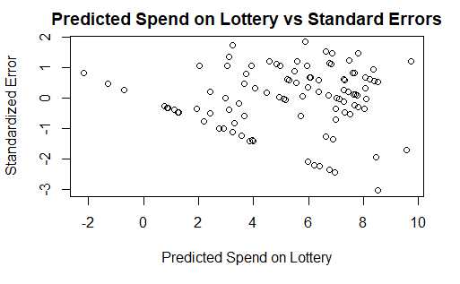

```r
n <- length(lottery)
Data.Lottery <- cbind(education,age,children,income)
linearModelVar <- lm(lottery ~ Data.Lottery)
SE <- standarized_errors_MR(lottery, Data.Lottery)[,1]
a <- coef(linearModelVar)[1]
b <- coef(linearModelVar)[2]
c <- coef(linearModelVar)[3]
d <- coef(linearModelVar)[4]
e <- coef(linearModelVar)[5]
Price_p <- vector("double", length = n)
  for(i in 1:n) {
    Price_p[i] <- a + b * education[i] + c * age[i] + d * children[i] + e * income[i]
  }
plot(x = Price_p,y = SE,  xlab = "Predicted Spend on Lottery",  ylab = "Standardized Error", main = "Predicted Spend on Lottery vs Standard Errors")
```

3. Dependence of the Error Variable

   Hypothesis:

$$H_0:\ Randomness\ exists.\\
H_1:\ Randomness\ does\ not\ exist.$$

```r
library(randtests)
SE <- standarized_errors_MR(lottery, Data.Lottery)[,1]
Run_T <- runs.test(SE)
print(Run_T)
```

```
    Approximate runs rest

data:  SE
Runs = 51, p-value = 1
alternative hypothesis: two.sided
```

Conclusion: When n1=50 > 20, we can make a conclusion through p-value. Since p-value = 1 > 0.05, we don’t reject H0. There is no evidence to infer that the sample is not random.

## Outliers and Influential Obs

```r
n <- length(lottery)
Data.Lottery <- cbind(education,age,children,income)
linearModelVar <- lm(lottery ~ Data.Lottery)
SE <- standarized_errors_MR(lottery, Data.Lottery)[,1]
h <- standarized_errors_MR(lottery, Data.Lottery)[,2]
D <- standarized_errors_MR(lottery, Data.Lottery)[,3]
#
cat("# # # # Outliers # # # ","\n")
```

```
# # # # Outliers # # #
```

```r
Outliers <- abs(SE) > 2
print(Outliers)
```

```
  [1] FALSE FALSE  TRUE FALSE FALSE FALSE FALSE FALSE FALSE
 [10] FALSE FALSE FALSE FALSE FALSE FALSE FALSE FALSE FALSE
 [19] FALSE FALSE FALSE FALSE FALSE FALSE FALSE FALSE FALSE
 [28] FALSE FALSE FALSE FALSE FALSE FALSE FALSE FALSE FALSE
 [37] FALSE FALSE FALSE FALSE FALSE FALSE FALSE FALSE FALSE
 [46] FALSE FALSE FALSE FALSE FALSE FALSE  TRUE FALSE FALSE
 [55] FALSE FALSE FALSE FALSE FALSE FALSE FALSE FALSE  TRUE
 [64] FALSE FALSE  TRUE FALSE FALSE FALSE FALSE FALSE FALSE
 [73] FALSE FALSE FALSE FALSE FALSE FALSE FALSE FALSE FALSE
 [82] FALSE FALSE FALSE FALSE FALSE  TRUE FALSE FALSE FALSE
 [91] FALSE FALSE FALSE  TRUE FALSE FALSE FALSE FALSE FALSE
[100] FALSE
```

```r
cat("     ","\n")
```

```r
cat("# # # # Influential Observations by h # # # ","\n")
```

```
# # # # Influential Observations by h # # #
```

```r
k <- dim(Data.Lottery)[2]
Inf_Obs <- h > 3*(k+1)/n
print(Inf_Obs)
```

```
  [1] FALSE FALSE FALSE FALSE FALSE FALSE FALSE FALSE FALSE
 [10] FALSE FALSE FALSE FALSE FALSE FALSE FALSE FALSE FALSE
 [19] FALSE FALSE FALSE FALSE FALSE FALSE FALSE FALSE FALSE
 [28] FALSE FALSE FALSE FALSE FALSE FALSE FALSE FALSE FALSE
 [37] FALSE FALSE FALSE FALSE FALSE FALSE FALSE FALSE FALSE
 [46] FALSE FALSE FALSE FALSE FALSE FALSE FALSE FALSE FALSE
 [55] FALSE FALSE FALSE FALSE FALSE FALSE  TRUE  TRUE FALSE
 [64] FALSE FALSE FALSE FALSE FALSE FALSE FALSE FALSE FALSE
 [73] FALSE FALSE FALSE FALSE FALSE FALSE FALSE FALSE FALSE
 [82] FALSE FALSE FALSE FALSE FALSE FALSE FALSE FALSE FALSE
 [91] FALSE FALSE FALSE FALSE FALSE FALSE FALSE FALSE FALSE
[100] FALSE
```

```r
cat("     ","\n")
```

```r
cat("# # # # Influential Observations # # # ","\n")
```

```
# # # # Influential Observations # # #
```

```r
Inf_Obs <- D > 1
print(Inf_Obs)
```

```
  [1] FALSE FALSE FALSE FALSE FALSE FALSE FALSE FALSE FALSE
 [10] FALSE FALSE FALSE FALSE FALSE FALSE FALSE FALSE FALSE
 [19] FALSE FALSE FALSE FALSE FALSE FALSE FALSE FALSE FALSE
 [28] FALSE FALSE FALSE FALSE FALSE FALSE FALSE FALSE FALSE
 [37] FALSE FALSE FALSE FALSE FALSE FALSE FALSE FALSE FALSE
 [46] FALSE FALSE FALSE FALSE FALSE FALSE FALSE FALSE FALSE
 [55] FALSE FALSE FALSE FALSE FALSE FALSE FALSE FALSE FALSE
 [64] FALSE FALSE FALSE FALSE FALSE FALSE FALSE FALSE FALSE
 [73] FALSE FALSE FALSE FALSE FALSE FALSE FALSE FALSE FALSE
 [82] FALSE FALSE FALSE FALSE FALSE FALSE FALSE FALSE FALSE
 [91] FALSE FALSE FALSE FALSE FALSE FALSE FALSE FALSE FALSE
[100] FALSE
```

Conclusion: Samples 3, 52, 63, 66, 87 and 94 are outliers because their standardized residuals are larger than 2 or smaller than –2. Samples 61, 62 are influential observations because their h are larger than 3*(k+1)/n.

# grade 71

```
17.03 (b)解釋不佳 -1 17.03 (e)解釋不佳 -1 17.03 (f)錯誤 -9 17.07 (e)錯誤 -7 17.07 (h)解釋不佳 -1 17.13 (c)錯誤 -9 17.13 方差解釋不佳 -1
```